# 決定木アルゴリズム

最適化

川田恵介

# ここまでのまとめ

- 母平均関数 $E_P[Y|X]$ が理想的な予測モデル
- 理想的な予測モデルに近づけるには、 “適度に”複雑なモデルが必要

## 数値例: 母平均関数

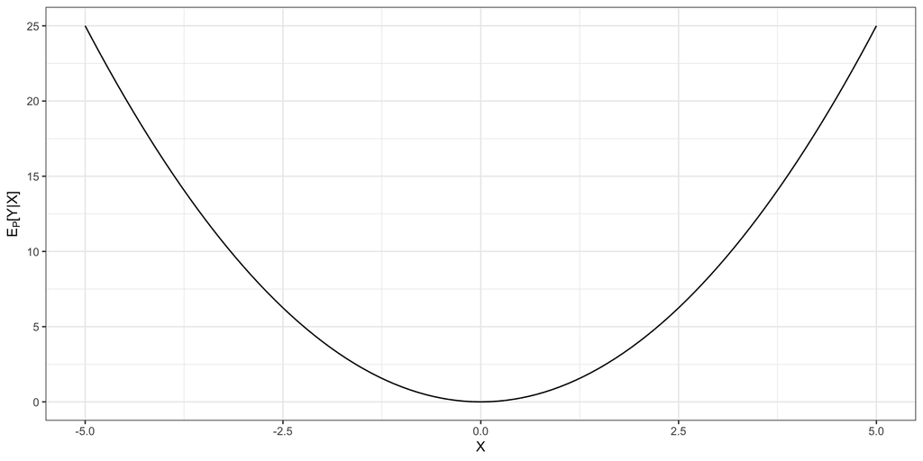

## 数値例: データ

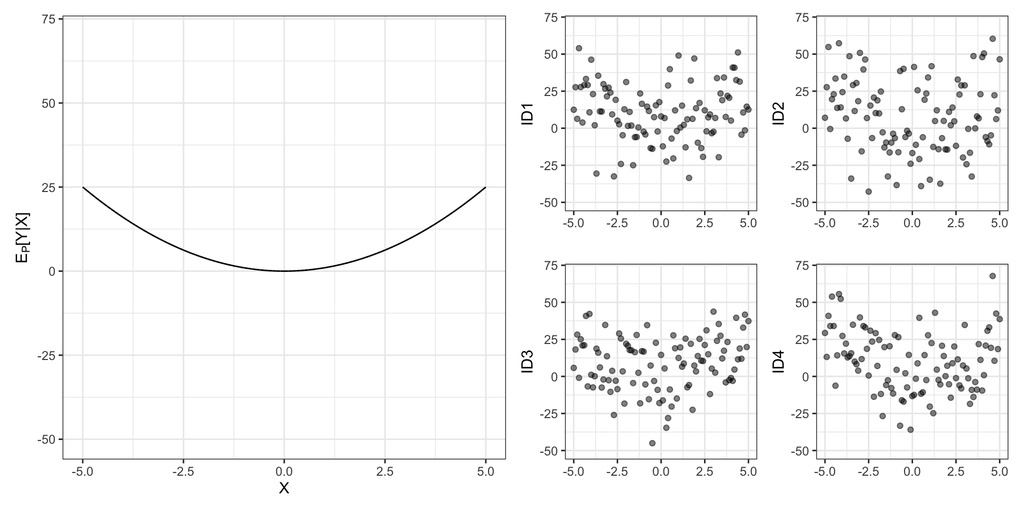

## 数値例: 浅い決定木

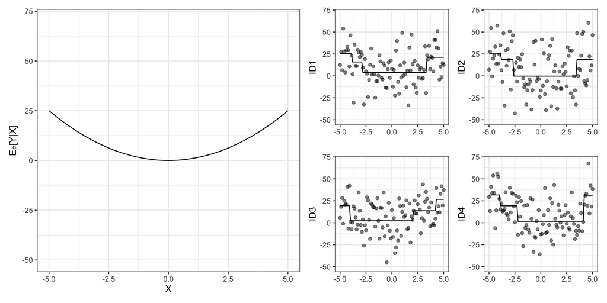

## 数値例: 深い決定木

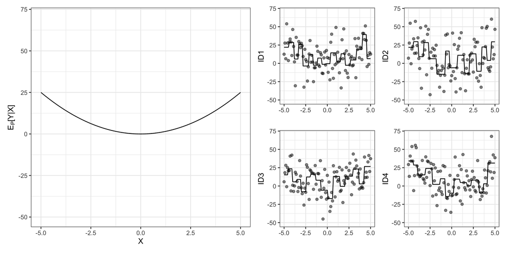

## 数値例: 丸暗記

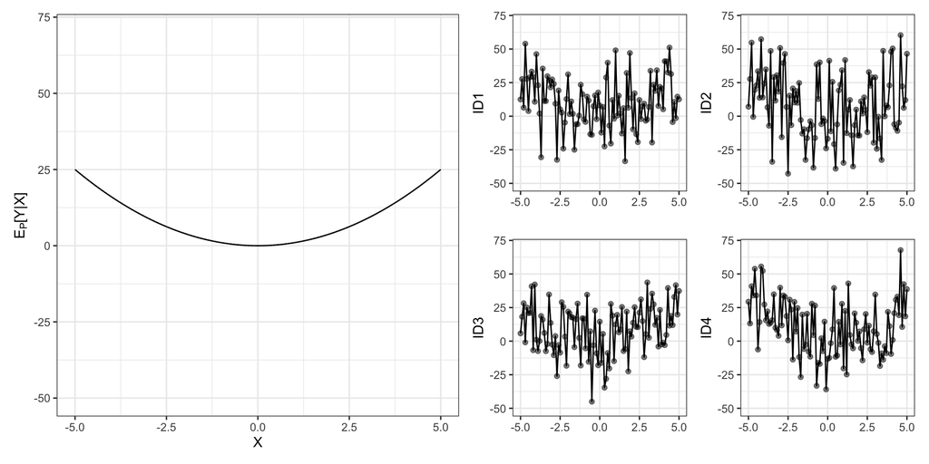

# 剪定

- 剪定: 一旦非常に深い木を推定した後に、単純化を行う

## Step 1. 深い木の推定

- 停止条件を緩めると、一般にどこまでもサブサンプル分割が行われる
  - 平均値が異なるサブグループが見つかる限り止まらない

## 数値例: サイコロゲーム

- ディーラーは、サイコロを5つふり、4つ $(X_1,..,X_4)$ プレイヤーに見せる
  - プレイヤーは残り一つの出目 $Y$ を予測
- サイコロの出目は、uniform分布 (完全無相関)に決定
  - 理想の予測モデル $g(X_1,..,X_4)$
- “見”を200回行いデータ収集

## 例

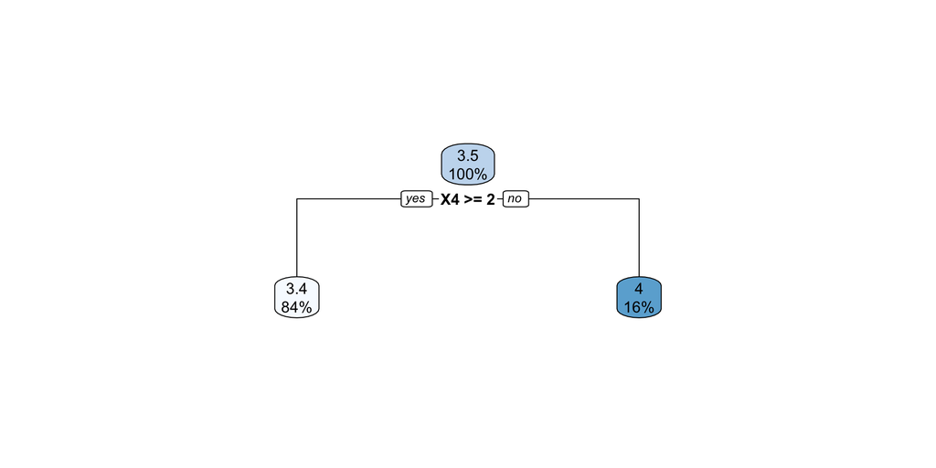

## 例

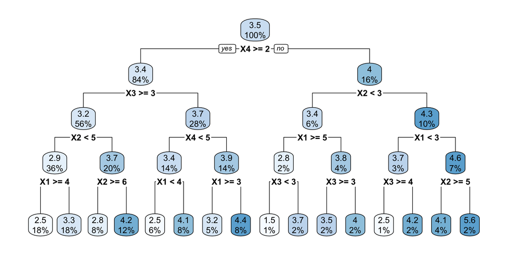

## Setp 2. 剪定

- 分割しても、データへの適合が悪化しずらいサブグループから再結合していく
  - 小規模なサブグループを分割している
  - 分割しても予測値があまり変化しない

## 例: 剪定

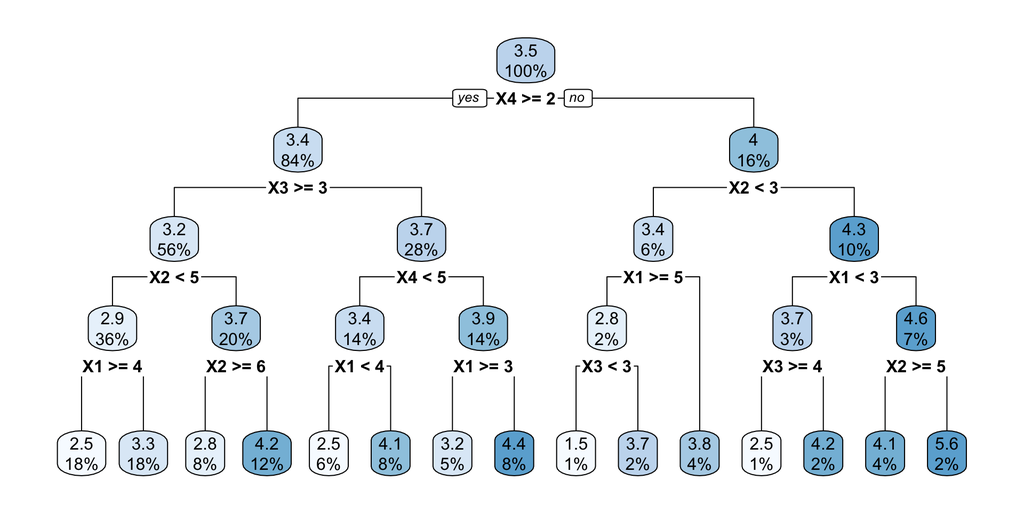

## 例: 剪定

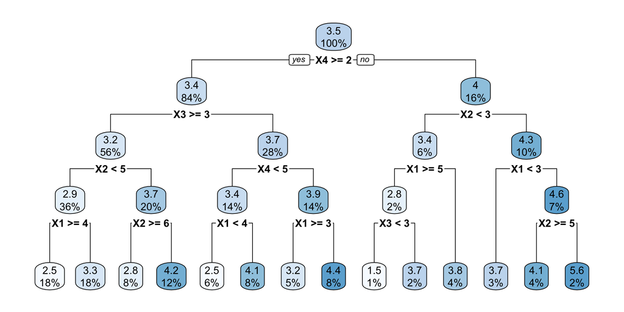

## 最適化問題の活用

- 残された問題は、どこまで剪定するか?
  - 剪定の水準をどのようにコントロールするか?
- 最適化問題に落とし込む
  - 何をやっているか(慣れれば)わかりやすく、自由度が高く、PCにも優しい枠組み

## 最適化問題

- “ある指標を最大化/最小化するように、決定する”枠組み
  - 経済学: 効用最大化問題の結果として財の購入、利潤最大化問題として生産計画、社会厚生最大化として政策

## 練習問題

- 以下を **最小化** するようにサブグループを再結合できない

$$データにおける二乗誤差$$

- 剪定が行われず、複雑になりすぎる
  - 経済学: 公害物質が排出されすぎる、騒音がですぎる

## 罰則付き最適化

- 以下を **最小化** するようにサブグループを再結合

$$データにおける二乗誤差 + \underbrace{\lambda \times \bigr| サブグループの数 \bigr|}_{罰則項}$$

- $\lambda$ : Hyper Parameter (rpart関数では cp)
  - 罰則項 $=$ 複雑性への”課税”

## まとめ

- 「データへの当てはまり改善」は活用
  - そのままでは複雑になりすぎるので、複雑さへの課税でコントロール
- 経済学でもお馴染みのアイディア
  - “市場”を一切活用していない”都市”は”存在しない”
  - 完全に”市場”任せにすると問題が生じるので、政策介入(課税/補助金など)をする

# モデルの試作と評価

- 最適な課税水準をどのように決めるのか
- 社会政策とは異なり
  - 目標が明確 (予測性能の改善)
  - 実験の費用が安い
- 「特定の課税水準のもとでモデルを試作し、中間評価する」を繰り返すことで最適な水準を探り出す

## 評価

- 現代PCを使えば、モデルの試作は簡単
- 難しいのは適切な評価
  - モデルの試作に用いたデータは使用できない
  - 理論的指標は色々提案されているが (AIC,BICなど)、使える状況は”限られている”

## データ分割法

- 本来やりたいことは、“新しい”事例を予測しやすいモデルを選ぶこと
- 元々のデータをランダムに2分割することで、擬似的に新しいデータを作り出す
  - モデル試作用データ $:=$ 訓練データ
  - 検証用データ $:=$ 検証データ

## 数値例: 深い決定木

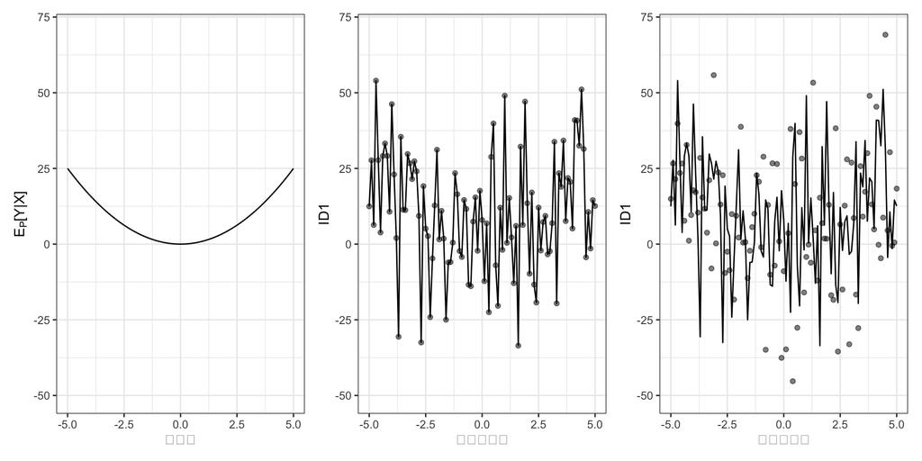

## 数値例: 間違った評価法

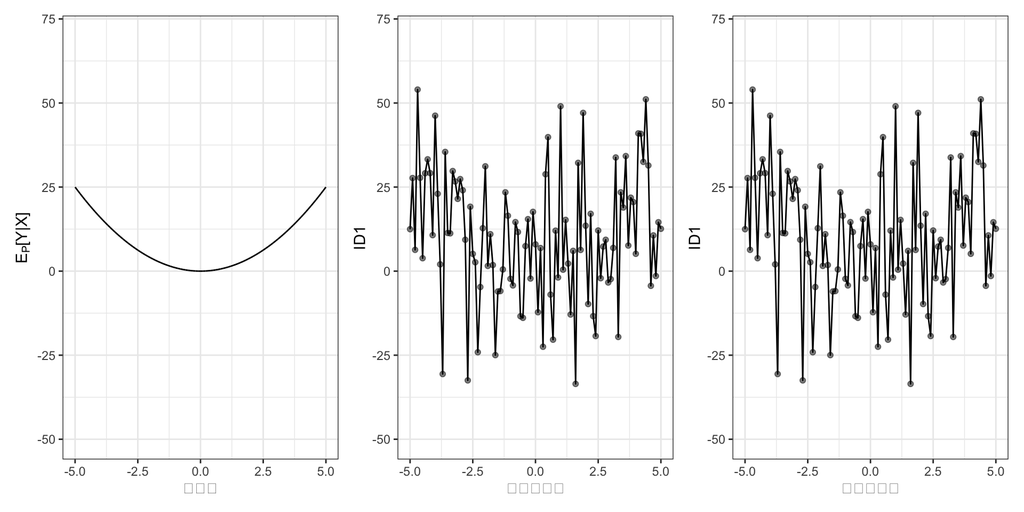

## データ分割法の手順

1. サンプルをランダムに2分割する
2. 検証対象とする $\lambda$ を設定
   - 訓練データを用いて決定木を推定
   - 検証データでテスト
3. 2を異なる $\lambda$ について繰り返し、最も検証データへの当てはまりが良くなる $\lambda$ を探す
4. 最善の$\lambda$ と全データを用いて、決定木を推定

## まとめ

- 同じデータで、モデル試作と評価はできない!!!
- 資格試験勉強の比喩
  - 過去問を繰り返しとき、答え合わせをすることで、試験対策を学習
  - 学習した方法の有効性を同じ過去問でテスト…?
  - 可能であればもしでテスト、不可能ならば過去問の一部は答えを見ずに残しておく

# 交差推定

- 訓練/評価 データが、ランダムに分割されていればOK
  - “役割の固定”は本質ではない

## 交差推定

1. データをいくつか (2,5,10,20など)に分割
2. 第1サブデータ **以外** を用いて予測モデルを試作
3. 第1サブデータに予測値を適用
4. 全てのサブデータに2,3を繰り返す

## 交差検証

- Cross validation
5. 交差推定で導出した予測値と実現値について、予測誤差を推定

## 数値例: 単純平均 VS 決定木(深さ2)

```
# A tibble: 6 × 3
  Group     Y     X
  <dbl> <dbl> <dbl>
1     1     6     3
2     1     7     1
3     2     4     3
4     2     5     2
5     3     4     1
6     3     4     1
```

## 数値例: 単純平均 VS 決定木(深さ2)

```
# A tibble: 6 × 5
  Group     Y     X PredMean PredTree
  <dbl> <dbl> <dbl>    <dbl>    <dbl>
1     1     6     3     4.25        4
2     1     7     1     4.25        4
3     2     4     3    NA          NA
4     2     5     2    NA          NA
5     3     4     1    NA          NA
6     3     4     1    NA          NA
```

## 数値例: 単純平均

```
# A tibble: 6 × 5
  Group     Y     X PredMean PredTree
  <dbl> <dbl> <dbl>    <dbl>    <dbl>
1     1     6     3     4.25        4
2     1     7     1     4.25        4
3     2     4     3     5.25        6
4     2     5     2     5.25        6
5     3     4     1    NA          NA
6     3     4     1    NA          NA
```

## 数値例: 単純平均

```
# A tibble: 6 × 5
  Group     Y     X PredMean PredTree
  <dbl> <dbl> <dbl>    <dbl>    <dbl>
1     1     6     3     4.25        4
2     1     7     1     4.25        4
3     2     4     3     5.25        6
4     2     5     2     5.25        6
5     3     4     1     5.5         7
6     3     4     1     5.5         7
```

## 数値例: 単純平均

```
# A tibble: 6 × 7
  Group     Y     X PredMean PredTree ErrorMean ErrorTree
  <dbl> <dbl> <dbl>    <dbl>    <dbl>     <dbl>     <dbl>
1     1     6     3     4.25        4    3.06           4
2     1     7     1     4.25        4    7.56           9
3     2     4     3     5.25        6    1.56           4
4     2     5     2     5.25        6    0.0625         1
5     3     4     1     5.5         7    2.25           9
6     3     4     1     5.5         7    2.25           9
```

- 平均二乗誤差(Mean) 2.79
- 平均二乗誤差(Tree) 6

## トレードオフの緩和

- サンプル分割法では、 訓練に多くの事例を割くと、 評価に割ける事例が減り、評価の精度が下がる
- 交差検証では、すべての事例について予測値を計算し、その平均を取るので、評価の精度を確保できる

## まとめ

- 複雑なモデルの推定は、現代的なPC + アルゴリズムであれば容易
- モデルを適切に単純化することに工夫が必要
- ２度漬け禁止の大原則
  - モデルの推定に使ったデータは、評価に原則使わない